# Frequently Asked Questions

## 6.4. How to assess the goodness-of-fit of a distribution fitted on censored data ?

The only available method in `fitdistrplus` to fit distributions on censored data is the maximum likelihood estimation (MLE). Once a distribution is fitted using `fitdistcens`, AIC and BIC values can be found in the `summary` of the object of class `fitdistcens` returned by the function. Those values can be used to compare the fit of various distributions on a same dataset. Function `gofstat` is not yet proposed in our package for fits on censored data but we plan to develop it in the future with the calculation of other goodness-of-fit statistics for censored data.

```r
fnorm <- fitdistcens(dsmo,"norm")
flogis <- fitdistcens(dsmo,"logis")
# comparison of AIC values
summary(fnorm)$aic
```

```
## [1] 178
```

```r
summary(flogis)$aic
```

```
## [1] 177
```

Considering goodness-of-fit plots, the generic `plot` function of an object of class `fitdistcens`provides three plots, one in CDF using the NPMLE ECDF plot (by default using the Wang prepresentation, see previous part for details), a Q-Q plot and a P-P plot simply derived from the Wang plot of the ECDF, with filled rectangles indicating non uniqueness of the NPMLE ECDF.

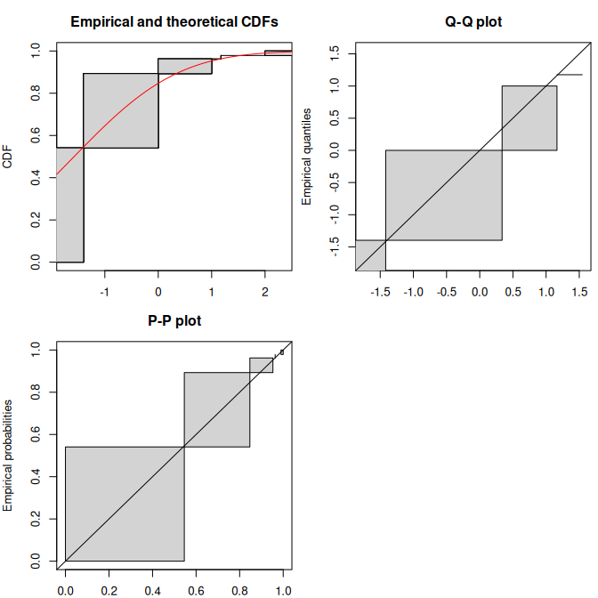

```r
par(mar = c(2, 4, 3, 0.5))
plot(fnorm)
```

Functions `cdfcompcens()`, `qqcompens()` and `ppcompcens()` can be used to individualize and personnalize CDF, Q-Q and P-P goodness-of-fit plots and/or to compare the fit of various distributions on a same dataset.

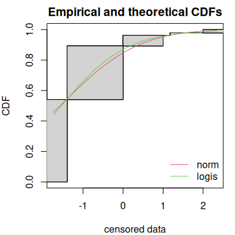

```r
par(mfrow=c(1,1), mar=c(4,4,2,1))
cdfcompcens(list(fnorm, flogis), fitlty = 1)
```

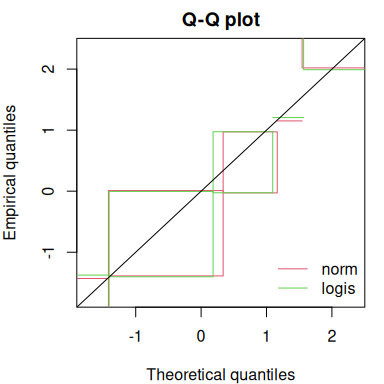

```r
qqcompcens(list(fnorm, flogis))
```

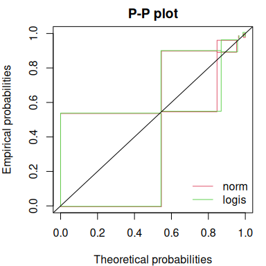

```r
ppcompcens(list(fnorm, flogis))
```

Considering Q-Q plots and P-P plots, it may be easier to compare various fits by splitting the plots as below which is done automatically using the `plotstyle` `ggplot` in `qqcompens()` and `ppcompcens()` but can also be done manually with the `plotstyle` `graphics`.

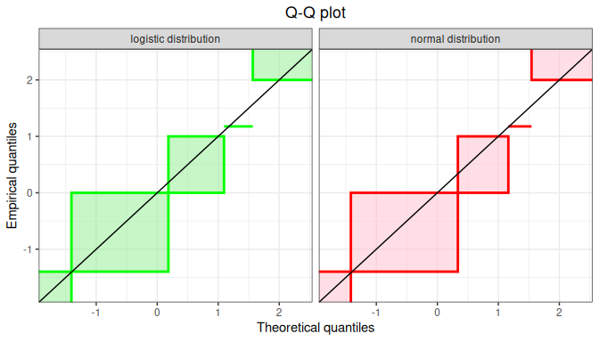

```r
qqcompcens(list(fnorm, flogis), lwd = 2, plotstyle = "ggplot",
  fitcol = c("red", "green"), fillrect = c("pink", "lightgreen"),
  legendtext = c("normal distribution", "logistic distribution"))
```